# Pentathlon III: Next Product to Buy Modeling

## Setup

Please complete this Rmarkdown document by answering the questions in `pentathlon-nptb.pdf` on Canvas (week8/). Create an Rmarkdown file with all your results and comments and push both the Rmarkdown and HTML file to GitLab when your team is done. All results MUST be reproducible (i.e., the TA and I must be able to recreate the HTML from the Jupyter Notebook file without changes or errors). This means that you should NOT use any python-packages that are not part of the rsm-msba-spark docker container.

This is the third group assignment for MGTA 455 and you will be using git and GitLab. If two people edit the same file at the same time you could get what is called a “merge conflict”. git will not decide for you who’s change to accept so the team-lead will have to determine which edits to use. To avoid merge conflicts, always “pull” changes to the repo before you start working on any files. Then, when you are done, save and commit your changes, and then push them to GitLab. Make “pull first” a habit!

```r
## loading the data - this dataset must NOT be changed
pentathlon_nptb <- readr::read_rds("data/pentathlon_nptb.rds")
# pentathlon_nptb <- readr::read_rds("data/pentathlon_nptb_5M.rds")
```

### 1. For each customer determine the message (i.e., endurance, strength, water, team, backcountry, winter, or racquet) predicted to lead to the highest probability of purchase. Describe your approach.

#### Train a model to predict probability

##### EDA :Inspect Demographic features, check the difference of proportion of buyers in each category.

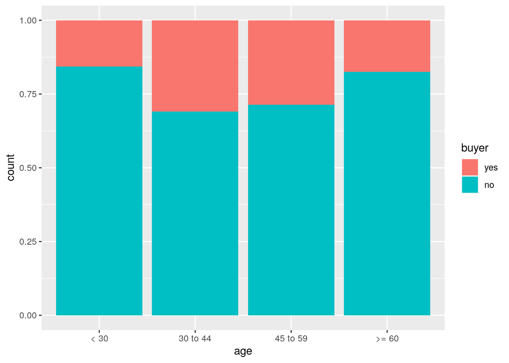

```r
pentathlon_nptb_realdata=pentathlon_nptb %>% filter(representative == 1)

# age: relatively obvious
age=pentathlon_nptb_realdata %>% group_by(age) %>% summarize(num_buyer=sum(buyer=='yes'),people=n(),prop_buyer=num_buyer/people) %>% arrange(desc(prop_buyer))

# gender: no large difference
gender=pentathlon_nptb_realdata %>% group_by(gender) %>% summarize(num_buyer=sum(buyer=='yes'),people=n(),prop_buyer=num_buyer/people) %>% arrange(desc(prop_buyer))


## cut into bins

pentathlon_nptb_bins=pentathlon_nptb_realdata %>% mutate(income_bins=xtile(income,10),education_bins=xtile(education,10),child_bins=xtile(children,10))

income=pentathlon_nptb_bins%>% group_by(income_bins) %>% summarize(num_buyer=sum(buyer=='yes'),people=n(),prop_buyer=num_buyer/people) %>% arrange(desc(prop_buyer))

# children: no large difference
children=pentathlon_nptb_bins%>% group_by(child_bins) %>% summarize(num_buyer=sum(buyer=='yes'),people=n(),prop_buyer=num_buyer/people) %>% arrange(desc(prop_buyer))

# education: obvious
education=pentathlon_nptb_bins%>% group_by(education_bins) %>% summarize(num_buyer=sum(buyer=='yes'),people=n(),prop_buyer=num_buyer/people) %>% arrange(desc(prop_buyer))


pentathlon_nptb %>%
  ggplot(aes(x=age,fill=buyer)) + geom_bar(position='fill') + xlab('age')
```

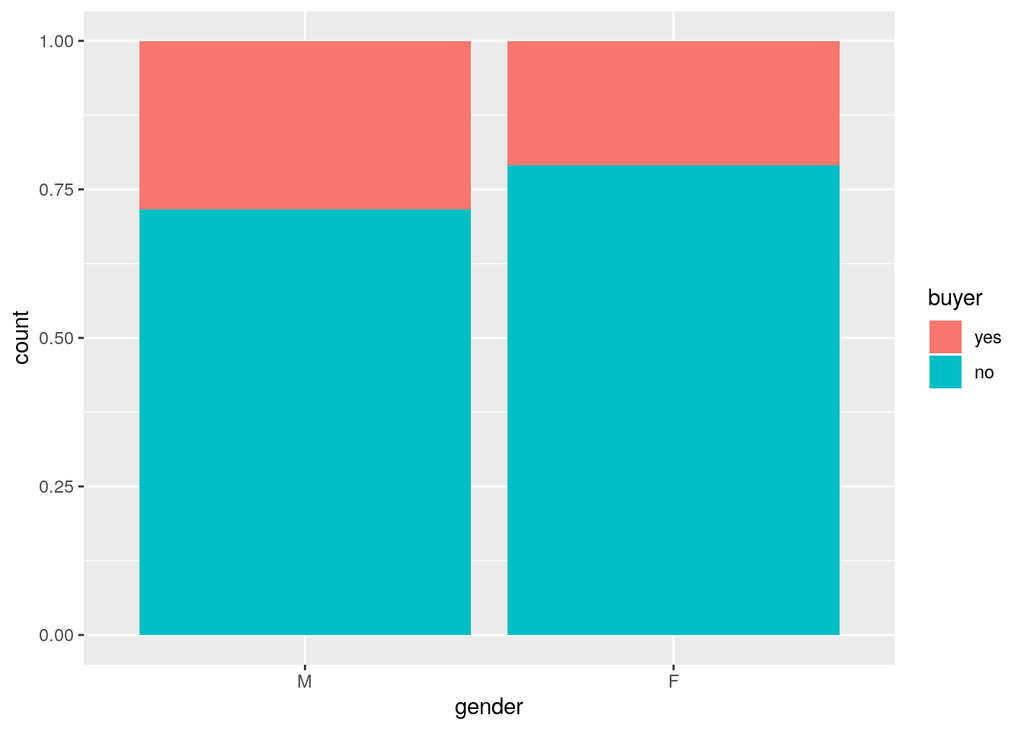

```r
pentathlon_nptb %>%
  ggplot(aes(x=gender,fill=buyer)) + geom_bar(position='fill') + xlab('gender')
```

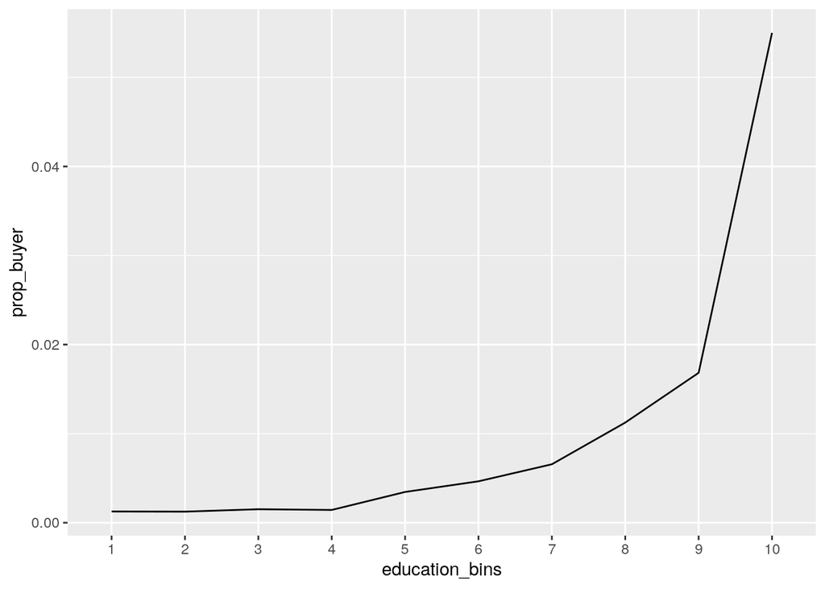

```r
education %>%
  ggplot(aes(x=factor(education_bins),y=prop_buyer,group=1)) + geom_line() + xlab('education_bins')
```

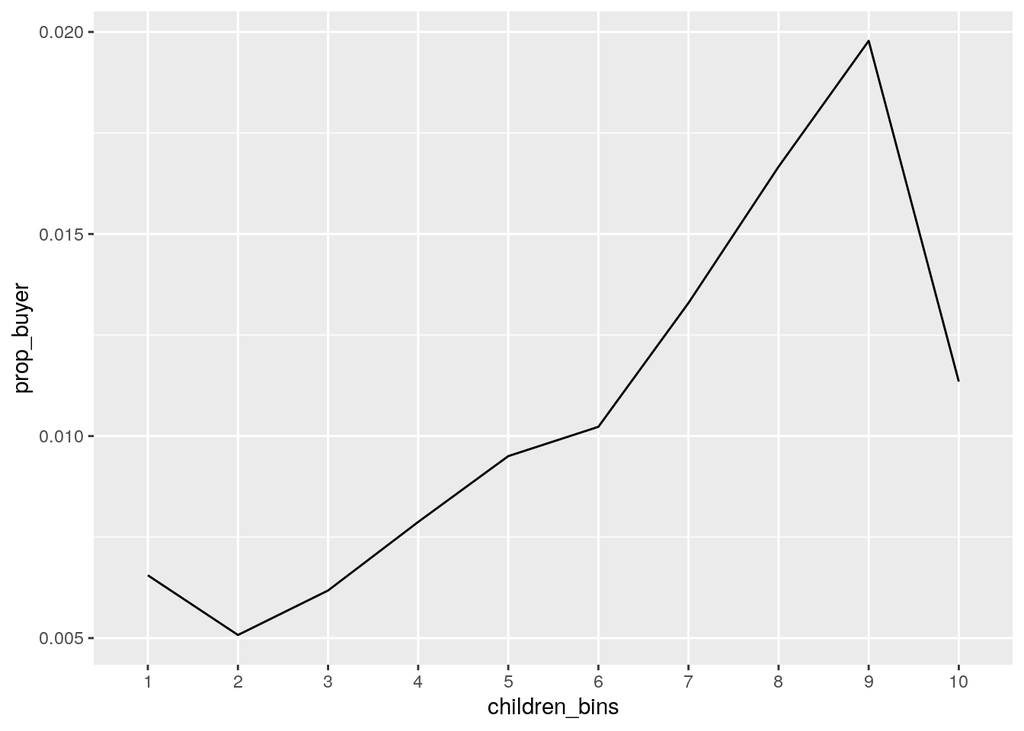

```r
children %>%
  ggplot(aes(x=factor(child_bins),y=prop_buyer,group=1)) + geom_line() + xlab('children_bins')
```

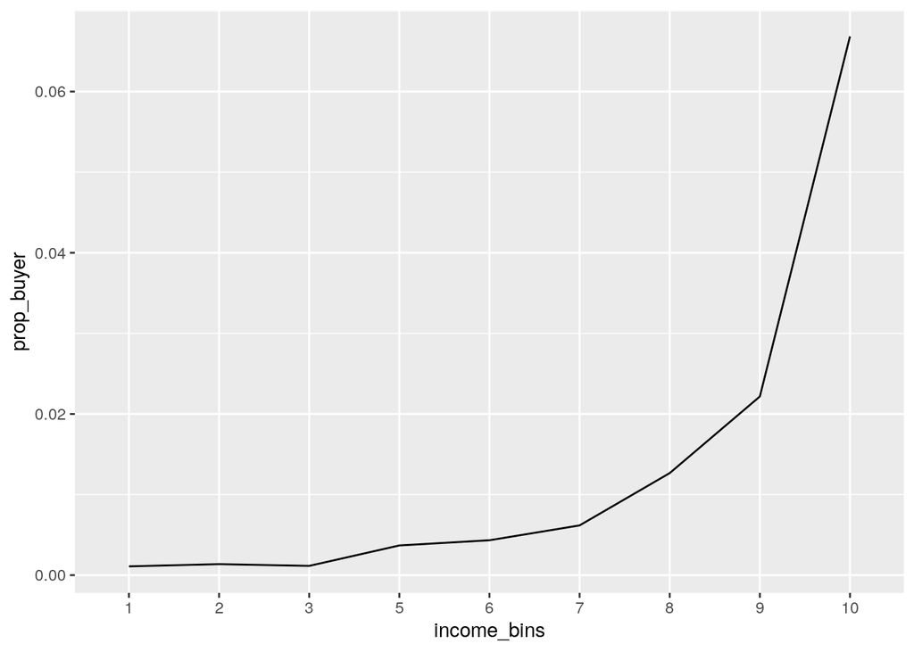

```r
income %>%
  ggplot(aes(x=factor(income_bins),y=prop_buyer,group=1)) + geom_line() + xlab('income_bins')
```

## Model1: lr model:

### basic:

```r
pentathlon_nptb=pentathlon_nptb %>% mutate(label= buyer=="yes")

traindata= pentathlon_nptb %>% filter(training == 1) %>% mutate(cweight = ifelse(buyer == 'yes', 1L, 99L))
testdata= pentathlon_nptb %>% filter(training != 1)

rvar="buyer"
evar=c("age","gender","education","income","children","message","freq_endurance","freq_strength","freq_water","freq_team","freq_backcountry", "freq_winter", "freq_racquet")
lev='yes'

f1 = radiant.model::logistic(traindata,rvar=rvar,evar=evar,lev=lev,wts=traindata$cweight)
res1=predict(f1, pred_data = testdata)
```

### cut income, education, children into bins:

```r
traindata2=traindata%>% mutate(income_bins=xtile(income,10),education_bins=xtile(education,10),child_bins=xtile(children,10)) %>% mutate(cweight = ifelse(buyer == 'yes', 1L, 99L))

testdata2=testdata%>% mutate(income_bins=xtile(income,10),education_bins=xtile(education,10),child_bins=xtile(children,10))

rvar="buyer"
evar2=c("age","gender","education_bins","income_bins","child_bins","message","freq_endurance","freq_strength","freq_water","freq_team","freq_backcountry", "freq_winter", "freq_racquet")

lev='yes'
f2 = radiant.model::logistic(traindata2,rvar=rvar,evar=evar2,lev=lev,wts=traindata2$cweight)
res2=predict(f2, pred_data = testdata2)
```

### interaction:

```r
traindata3=traindata2

testdata3=testdata2

rvar="buyer"
evar3=c("age","gender","education_bins","income_bins","child_bins","message","freq_endurance","freq_strength","freq_water","freq_team","freq_backcountry", "freq_winter", "freq_racquet")

int=c("message:freq_endurance","message:freq_strength","message:freq_water","message:freq_team","message:freq_backcountry", "message:freq_winter", "message:freq_racquet","age:gender")

lev='yes'

f3 = radiant.model::logistic(traindata3,rvar=rvar,evar=evar3,int=int,wts=traindata3$cweight)
res3=predict(f3, pred_data = testdata3)
```

```r
traindata4=traindata3 %>% mutate(education_10=ifelse(education_bins==10,1,0),income_10=ifelse(income_bins==10,1,0))

testdata4=testdata3 %>% mutate(education_10=ifelse(education_bins==10,1,0),income_10=ifelse(income_bins==10,1,0))


rvar="buyer"
evar4=c("age","gender","education_bins","income_bins","child_bins","message","freq_endurance","freq_strength","freq_water","freq_team","freq_backcountry", "freq_winter", "freq_racquet","education_10","income_10")

int=c("message:freq_endurance","message:freq_strength","message:freq_water","message:freq_team","message:freq_backcountry", "message:freq_winter", "message:freq_racquet")

lev='yes'

f4 = radiant.model::logistic(traindata4,rvar=rvar,evar=evar4,int=int,wts=traindata4$cweight)
res4=predict(f4, pred_data = testdata4)
```

### evaluate model by auc

```r
auc1=ModelMetrics::auc(testdata$label,res1$Prediction)
auc2=ModelMetrics::auc(testdata2$label,res2$Prediction)
auc3=ModelMetrics::auc(testdata3$label,res3$Prediction)
auc4=ModelMetrics::auc(testdata4$label,res4$Prediction)
auc1
```

```
[1] 0.8823285
```

```r
auc2
```

```
[1] 0.8824458
```

```r
auc3
```

```
[1] 0.8818373
```

```r
auc4
```

```
[1] 0.8817732
```

## NN:

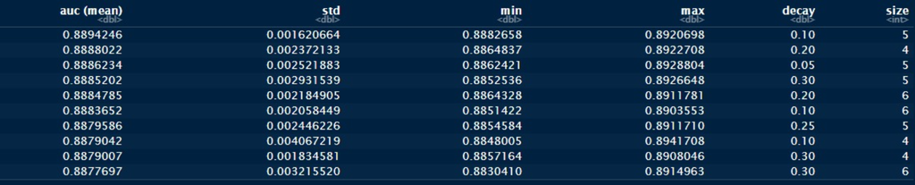

result of cross validation of NN

```r
nnmodel <- nn(
  traindata,
  rvar = rvar,
  evar = evar,
  lev = lev,
  size=5,
  decay=0.1,
  wts="cweight",
  seed=1234
)

pred_pro=predict(nnmodel, pred_data=testdata)
auc_nn=ModelMetrics::auc(testdata$label,pred_pro$Prediction)
auc_nn
```

```
[1] 0.8880054
```

xgboost and random forest model please see python notebook.

[figure not shown]

classifier model comparision

So we use nn model to predict the probability:

1. For each customer determine the message (i.e., endurance, strength, water, team, backcountry, winter, or racquet) predicted to lead to the highest probability of purchase. Describe your approach.

```r
rep=pentathlon_nptb %>% filter(representative == 1)
rep=rep%>% mutate(income_bins=xtile(income,10),education_bins=xtile(education,10),child_bins=xtile(children,10))


backcountry_prob=predict(nnmodel,pred_data=rep,pred_cmd="message='backcountry'")
rep=store(rep,backcountry_prob,name='backcountry_prob')
endurance_prob=predict(nnmodel,pred_data=rep,pred_cmd="message='endurance'")
rep=store(rep,endurance_prob,name='endurance_prob')
racquet_prob=predict(nnmodel,pred_data=rep,pred_cmd="message='racquet'")
rep=store(rep,racquet_prob,name='racquet_prob')
strength_prob=predict(nnmodel,pred_data=rep,pred_cmd="message='strength'")
rep=store(rep,strength_prob,name='strength_prob')
team_prob=predict(nnmodel,pred_data=rep,pred_cmd="message='team'")
rep=store(rep,team_prob,name='team_prob')
water_prob=predict(nnmodel,pred_data=rep,pred_cmd="message='water'")
rep=store(rep,water_prob,name='water_prob')
winter_prob=predict(nnmodel,pred_data=rep,pred_cmd="message='winter'")
rep=store(rep,winter_prob,name='winter_prob')

rep=rep%>% mutate(to_message=c('backcountry','endurance','racquet','strength','team','water','winter')[which.pmax(backcountry_prob,endurance_prob,racquet_prob,strength_prob,team_prob,water_prob,winter_prob)])

rep
```

[output not shown]

[output cut: 258 more lines]

2. For each message, report the percentage of customers for whom that message maximizes their probability of purchase.

```r
prob_customer_percentage=rep %>% group_by(to_message) %>% summarize(n=n(),percentage=n/nrow(rep)) %>% arrange(desc(percentage))
prob_customer_percentage
```

```
# A tibble: 7 x 3
  to_message      n percentage
  <chr>       <int>      <dbl>
1 endurance   63225    0.632
2 strength    26444    0.264
3 racquet      4290    0.0429
4 water        3560    0.0356
5 team         1966    0.0197
6 backcountry   483    0.00483
7 winter         32    0.00032
```

3. For each customer, determine the message (i.e., endurance, strength, water, team, backcountry, winter, or racquet) predicted to lead to the highest expected profit (COGS is 60%). Describe your approach to predict order size and how you calculated expected profit.

# linear regression model 1

```r
evar=c("age","gender","education","income","children","message","freq_endurance","freq_strength","freq_water","freq_team","freq_backcountry", "freq_winter", "freq_racquet")

linearmodel1 <- regress(traindata, rvar = 'total_os', evar =evar,int=c("message:freq_endurance","message:freq_strength","message:freq_water","message:freq_team","message:freq_backcountry", "message:freq_winter", "message:age","message:gender","message:education","message:children","message:income"))
pred1=predict(linearmodel1,pred_data=testdata)

testdata$resi= testdata$total_os-pred1$Prediction
RMSE1=sqrt(mean(testdata$resi^2))
RMSE1
```

```
[1] 46.00005
```

# linear regression model 2

```r
evar=c("age","gender","education","income","children","message","freq_endurance","freq_strength","freq_water","freq_team","freq_backcountry", "freq_winter", "freq_racquet")
int=c("message:freq_endurance","message:freq_strength","message:freq_water","message:freq_team","message:freq_backcountry", "message:freq_winter", "message:freq_racquet","age:gender")

linearmodel2 <- regress(traindata, rvar = 'total_os', evar =evar,int=int)
pred2=predict(linearmodel2,pred_data=testdata)

testdata$resi2= testdata$total_os-pred2$Prediction
RMSE2=sqrt(mean(testdata$resi2^2))
RMSE2
```

```
[1] 45.98701
```

xgboost, mlp model please see python notebook.

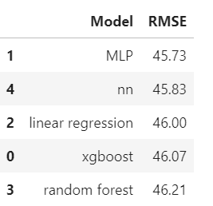

Finally, we use mlp model to predict total_ords and then calculate the expected profit by multiplying the probability of each product.

```r
repre_profit_deeplearning=read.csv("repre_profit_deeplearning.csv")


repre_profit_deeplearning <- select(repre_profit_deeplearning, c("endurance", "strength", "water", "team", "backcountry", "winter", "racquet"))

repre_profit_deeplearning[repre_profit_deeplearning < 0] <- 0

b=repre_profit_deeplearning$backcountry
e=repre_profit_deeplearning$endurance
r=repre_profit_deeplearning$racquet
s=repre_profit_deeplearning$strength
t=repre_profit_deeplearning$team
wa=repre_profit_deeplearning$water
wi=repre_profit_deeplearning$winter

rep_profit=rep%>% mutate(to_message=c('backcountry','endurance','racquet','strength','team','water','winter')[which.pmax(backcountry_prob*b,endurance_prob*e,racquet_prob*r,strength_prob*s,team_prob*t,water_prob*wa,winter_prob*wi)])

rep_profit
```

[output not shown]

[output cut: 258 more lines]

4. Report for each message, i.e., endurance, racket, etc., the percentage of customers for whom that message maximizes their expected profit.

```r
profit_customer_percentage=rep_profit %>% group_by(to_message) %>% summarize(n=n(),percentage=n/nrow(rep_profit)) %>% arrange(desc(percentage))
profit_customer_percentage
```

```
# A tibble: 7 x 3
  to_message      n percentage
  <chr>       <int>      <dbl>
1 endurance   53770     0.538
2 strength    19892     0.199
3 backcountry 13238     0.132
4 water        5018     0.0502
5 racquet      4012     0.0401
6 winter       2375     0.0238
7 team         1695     0.0170
```

5. What expected profit can we obtain, on average, per e-mailed customer if we customize the message to each customer?

```r
rep_profit2=rep_profit %>% mutate(maximum_profit=pmax(backcountry_prob*b,endurance_prob*e,racquet_prob*r,strength_prob*s,team_prob*t,water_prob*wa,winter_prob*wi))
exp_profit_percustomer= sum(rep_profit2$maximum_profit)/nrow(rep)
exp_profit_percustomer
```

```
[1] 0.2403944
```

6. What is the expected profit per e-mailed customer if every customer receives the same message? Answer this question for each of the seven possible messages (i.e., endurance, strength, water, team, backcountry, winter, or racquet).

```r
rep_profit_each=rep_profit %>% mutate(backcountry_profit=backcountry_prob*b,endurance_profit=endurance_prob*e,racquet_profit=racquet_prob*r,strength_profit=strength_prob*s,team_profit=team_prob*t,water_profit=water_prob*wa,winter_profit=winter_prob*wi)

rep_profit_each_gather=rep_profit_each%>%
  gather(product,expected_profit,backcountry_profit:winter_profit)%>%
  group_by(product) %>%
  summarize(total_exp_profit=sum(expected_profit),profit_per_customer=total_exp_profit/nrow(rep_profit))%>%
  arrange(desc(profit_per_customer))

rep_profit_each_gather
```

```
# A tibble: 7 x 3
  product            total_exp_profit profit_per_customer
  <chr>                         <dbl>               <dbl>
1 endurance_profit             22031.               0.220
2 strength_profit              21357.               0.214
3 water_profit                 19379.               0.194
4 winter_profit                18201.               0.182
5 racquet_profit               18131.               0.181
6 backcountry_profit           17493.               0.175
7 team_profit                  17269.               0.173
```

7. What is the expected profit per e-mailed customer if every customer is assigned randomly to one of the seven messages?

```r
random_exp_profit_percustomer=mean(rep_profit_each_gather$profit_per_customer)
random_exp_profit_percustomer
```

```
[1] 0.1912299
```

8. For the typical promotional e-mail blast to 5,000,000 customers, what improvement (in percent and in total Euros) could Pentathlon achieve by customizing the message to each customer rather than assigning customers a message randomly? You can, however, use this larger dataset to re-estimate your chosen model and generate profit estimates for the representative sample

```r
#in total Euros
total_euros=(exp_profit_percustomer-random_exp_profit_percustomer)*5000000
total_euros
```

```
[1] 245822.9
```

```r
#in percent
per=exp_profit_percustomer/random_exp_profit_percustomer-1
per
```

```
[1] 0.2570968
```

### proposal:

First, looking at our proportion analysis, we discovered that some products are popular (like endurance), and some are not popular whatsoever (such as team). Noting that, it is possible that down the road it will always be the two departments that are able to send the emails. In essence, the data will be self-reinforcing and skew the importance or probability of sale by department message. We will be lacking the data needed to determine if it is still wise to not send emails from the unpopular department. In order to improve, we suggest doing an AB test, or withholding a different part of the population every month in order to gain unbiased data for the model. Randomly selecting and rotating who is left out of the targeted marketing will continue to provide data that we can capitalize on to improve the model.

Finally, the first and second email to send could be vastly different in expected revenue. For instance, highest expected profits could be $7 for winter and $3 for team. It would be unwise to split the mail 50/50, as more should be focused on the winter category. We propose looking at the proportion of the expected profits and adjusting that way. So, in our example, if 10 emails were sent out, we would send an extra 2 emails to winter for a total of 7, and only 3 to team.